# Week 13: Model Evaluation and Selection

Comprehensive Guide to Evaluating Machine Learning Models

Instructor: Dr. Smith • Version: 0.12.0 • University of South Florida

# Model Evaluation and Selection

## Introduction

Model evaluation is a critical step in the machine learning workflow that determines how well your model performs on unseen data. In this lecture, we’ll explore comprehensive techniques for evaluating both regression and classification models, understanding various metrics, and learning how to select the best model for your business application.

## Learning Objectives

By the end of this lecture, you will be able to:

1. Understand and apply evaluation metrics for regression models
2. Master classification metrics including confusion matrices, precision, recall, and F1-score
3. Interpret ROC curves and AUC scores
4. Compare multiple models systematically
5. Understand cross-validation techniques
6. Apply model selection strategies to business problems

## Setup and Libraries

```python
import numpy as np
import pandas as pd
import matplotlib.pyplot as plt
import seaborn as sns
from sklearn.model_selection import train_test_split, cross_val_score, KFold
from sklearn.linear_model import LinearRegression, LogisticRegression
from sklearn.metrics import (
    # Regression metrics
    mean_squared_error, mean_absolute_error, r2_score, mean_absolute_percentage_error,
    # Classification metrics
    confusion_matrix, classification_report, accuracy_score,
    precision_score, recall_score, f1_score,
    roc_curve, auc, roc_auc_score
)
from sklearn.preprocessing import StandardScaler
import warnings
warnings.filterwarnings('ignore')

# Set visualization style
sns.set_style("whitegrid")
plt.rcParams['figure.figsize'] = (10, 6)

print("Libraries loaded successfully!")
```

```
Libraries loaded successfully!
```

## Part 1: Regression Model Evaluation

### 1.1 Key Regression Metrics

When evaluating regression models, we use several metrics to understand different aspects of model performance:

```python
# Generate sample regression data
np.random.seed(42)
n_samples = 200

# Create features
X = np.random.randn(n_samples, 3)
# Create target with some noise
true_weights = [3, -2, 1.5]
y_true = X @ true_weights + np.random.randn(n_samples) * 2

# Split data
X_train, X_test, y_train, y_test = train_test_split(X, y_true, test_size=0.3, random_state=42)

# Train model
reg_model = LinearRegression()
reg_model.fit(X_train, y_train)
y_pred = reg_model.predict(X_test)

# Calculate metrics
mse = mean_squared_error(y_test, y_pred)
rmse = np.sqrt(mse)
mae = mean_absolute_error(y_test, y_pred)
r2 = r2_score(y_test, y_pred)
mape = mean_absolute_percentage_error(y_test, y_pred)

print("Regression Model Evaluation Metrics:")
print("-" * 40)
print(f"Mean Squared Error (MSE):     {mse:.4f}")
print(f"Root Mean Squared Error (RMSE): {rmse:.4f}")
print(f"Mean Absolute Error (MAE):    {mae:.4f}")
print(f"R-squared (R²):               {r2:.4f}")
print(f"Mean Absolute Percentage Error: {mape:.2%}")
```

```
Regression Model Evaluation Metrics:
----------------------------------------
Mean Squared Error (MSE):     3.8662
Root Mean Squared Error (RMSE): 1.9663
Mean Absolute Error (MAE):    1.5873
R-squared (R²):               0.7963
Mean Absolute Percentage Error: 140.06%
```

### 1.2 Understanding Each Metric

**Regression Metrics Explained**

- **MSE**: Average squared difference between predicted and actual values. Penalizes large errors more.
- **RMSE**: Square root of MSE, in the same units as the target variable.
- **MAE**: Average absolute difference. Less sensitive to outliers than MSE.
- **R²**: Proportion of variance explained by the model (0 to 1, higher is better).
- **MAPE**: Average percentage error, useful for understanding relative error magnitude.

### 1.3 Visualizing Regression Performance

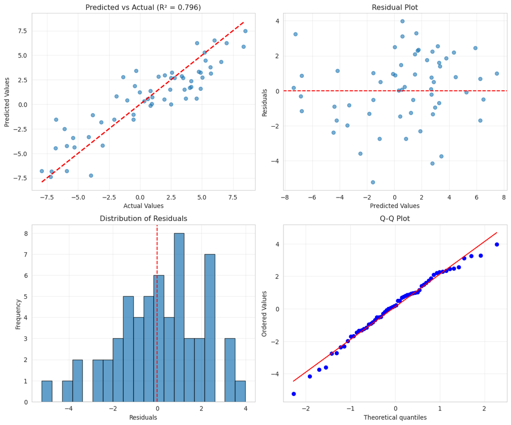

```python
fig, axes = plt.subplots(2, 2, figsize=(12, 10))

# 1. Predicted vs Actual
axes[0, 0].scatter(y_test, y_pred, alpha=0.6)
axes[0, 0].plot([y_test.min(), y_test.max()], [y_test.min(), y_test.max()], 'r--', lw=2)
axes[0, 0].set_xlabel('Actual Values')
axes[0, 0].set_ylabel('Predicted Values')
axes[0, 0].set_title(f'Predicted vs Actual (R² = {r2:.3f})')
axes[0, 0].grid(True, alpha=0.3)

# 2. Residuals Plot
residuals = y_test - y_pred
axes[0, 1].scatter(y_pred, residuals, alpha=0.6)
axes[0, 1].axhline(y=0, color='r', linestyle='--')
axes[0, 1].set_xlabel('Predicted Values')
axes[0, 1].set_ylabel('Residuals')
axes[0, 1].set_title('Residual Plot')
axes[0, 1].grid(True, alpha=0.3)

# 3. Residual Distribution
axes[1, 0].hist(residuals, bins=20, edgecolor='black', alpha=0.7)
axes[1, 0].set_xlabel('Residuals')
axes[1, 0].set_ylabel('Frequency')
axes[1, 0].set_title('Distribution of Residuals')
axes[1, 0].axvline(x=0, color='r', linestyle='--')
axes[1, 0].grid(True, alpha=0.3)

# 4. Q-Q Plot
from scipy import stats
stats.probplot(residuals, dist="norm", plot=axes[1, 1])
axes[1, 1].set_title('Q-Q Plot')
axes[1, 1].grid(True, alpha=0.3)

plt.tight_layout()
plt.show()
```

## Part 2: Classification Model Evaluation

### 2.1 Confusion Matrix

The confusion matrix is the foundation for understanding classification performance:

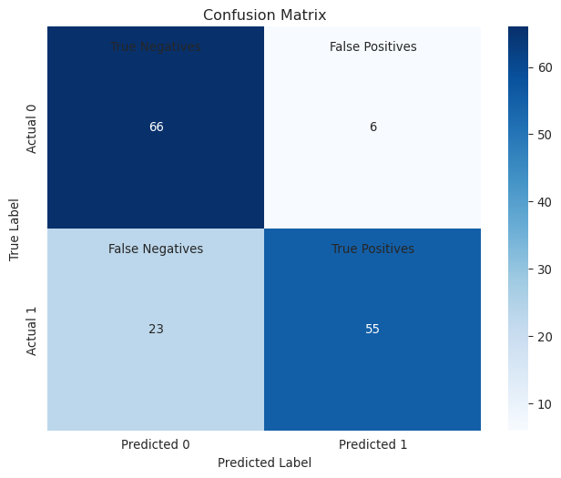

```
Confusion Matrix Breakdown:
True Negatives (TN):  66
False Positives (FP): 6
False Negatives (FN): 23
True Positives (TP):  55
```

```python
# Generate sample classification data
from sklearn.datasets import make_classification

X_class, y_class = make_classification(
    n_samples=500, n_features=10, n_informative=5,
    n_redundant=3, n_classes=2, random_state=42,
    class_sep=1.0
)

# Split data
X_train_c, X_test_c, y_train_c, y_test_c = train_test_split(
    X_class, y_class, test_size=0.3, random_state=42
)

# Train logistic regression
clf = LogisticRegression(random_state=42)
clf.fit(X_train_c, y_train_c)
y_pred_c = clf.predict(X_test_c)
y_pred_proba = clf.predict_proba(X_test_c)[:, 1]

# Create confusion matrix
cm = confusion_matrix(y_test_c, y_pred_c)

# Visualize confusion matrix
plt.figure(figsize=(8, 6))
sns.heatmap(cm, annot=True, fmt='d', cmap='Blues',
            xticklabels=['Predicted 0', 'Predicted 1'],
            yticklabels=['Actual 0', 'Actual 1'])
plt.title('Confusion Matrix')
plt.ylabel('True Label')
plt.xlabel('Predicted Label')

# Add text annotations for TP, TN, FP, FN
plt.text(0.5, 0.1, 'True Negatives', ha='center', va='center', fontsize=10)
plt.text(1.5, 0.1, 'False Positives', ha='center', va='center', fontsize=10)
plt.text(0.5, 1.1, 'False Negatives', ha='center', va='center', fontsize=10)
plt.text(1.5, 1.1, 'True Positives', ha='center', va='center', fontsize=10)

plt.show()

print("\nConfusion Matrix Breakdown:")
print(f"True Negatives (TN):  {cm[0, 0]}")
print(f"False Positives (FP): {cm[0, 1]}")
print(f"False Negatives (FN): {cm[1, 0]}")
print(f"True Positives (TP):  {cm[1, 1]}")
```

### 2.2 Classification Metrics

```python
# Calculate all metrics
accuracy = accuracy_score(y_test_c, y_pred_c)
precision = precision_score(y_test_c, y_pred_c)
recall = recall_score(y_test_c, y_pred_c)
f1 = f1_score(y_test_c, y_pred_c)

print("Classification Metrics:")
print("-" * 40)
print(f"Accuracy:  {accuracy:.4f}")
print(f"Precision: {precision:.4f}")
print(f"Recall:    {recall:.4f}")
print(f"F1-Score:  {f1:.4f}")

# Detailed classification report
print("\nDetailed Classification Report:")
print("-" * 40)
print(classification_report(y_test_c, y_pred_c,
                          target_names=['Class 0', 'Class 1']))
```

```
Classification Metrics:
----------------------------------------
Accuracy:  0.8067
Precision: 0.9016
Recall:    0.7051
F1-Score:  0.7914

Detailed Classification Report:
----------------------------------------
              precision    recall  f1-score   support

     Class 0       0.74      0.92      0.82        72
     Class 1       0.90      0.71      0.79        78

    accuracy                           0.81       150
   macro avg       0.82      0.81      0.81       150
weighted avg       0.82      0.81      0.81       150
```

### 2.3 Understanding Classification Metrics

**Key Classification Metrics**

**Accuracy** = (TP + TN) / Total - Overall correctness of the model - Can be misleading with imbalanced classes

**Precision** = TP / (TP + FP) - Of all positive predictions, how many were correct? - Important when false positives are costly

**Recall (Sensitivity)** = TP / (TP + FN) - Of all actual positives, how many did we identify? - Important when false negatives are costly

**F1-Score** = 2 × (Precision × Recall) / (Precision + Recall) - Harmonic mean of precision and recall - Good for imbalanced datasets

### 2.4 ROC Curve and AUC

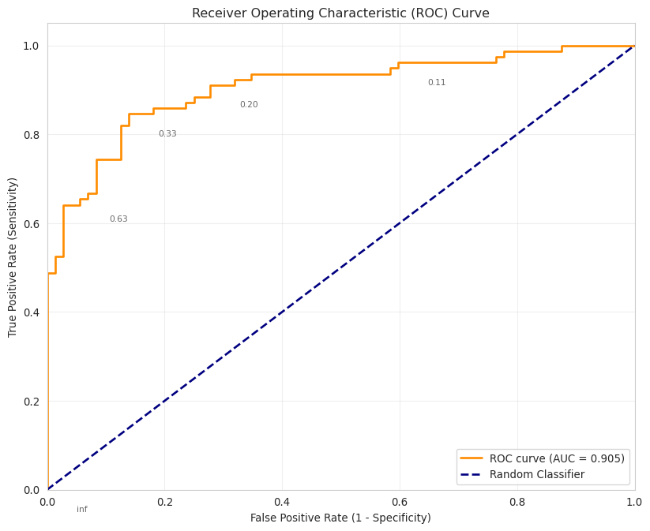

```
Area Under the Curve (AUC): 0.9047
```

```python
# Calculate ROC curve
fpr, tpr, thresholds = roc_curve(y_test_c, y_pred_proba)
roc_auc = auc(fpr, tpr)

# Plot ROC curve
plt.figure(figsize=(10, 8))
plt.plot(fpr, tpr, color='darkorange', lw=2,
         label=f'ROC curve (AUC = {roc_auc:.3f})')
plt.plot([0, 1], [0, 1], color='navy', lw=2, linestyle='--',
         label='Random Classifier')

# Add threshold annotations
for i in range(0, len(thresholds), len(thresholds)//5):
    plt.annotate(f'{thresholds[i]:.2f}',
                xy=(fpr[i], tpr[i]),
                xytext=(fpr[i]+0.05, tpr[i]-0.05),
                fontsize=8, alpha=0.7)

plt.xlim([0.0, 1.0])
plt.ylim([0.0, 1.05])
plt.xlabel('False Positive Rate (1 - Specificity)')
plt.ylabel('True Positive Rate (Sensitivity)')
plt.title('Receiver Operating Characteristic (ROC) Curve')
plt.legend(loc="lower right")
plt.grid(True, alpha=0.3)
plt.show()

print(f"Area Under the Curve (AUC): {roc_auc:.4f}")
```

### 2.5 Threshold Selection

```
Performance at Different Thresholds:
 Threshold  Accuracy  Precision   Recall  F1-Score
       0.3  0.833333   0.835443 0.846154  0.840764
       0.5  0.806667   0.901639 0.705128  0.791367
       0.7  0.780000   0.959184 0.602564  0.740157
```

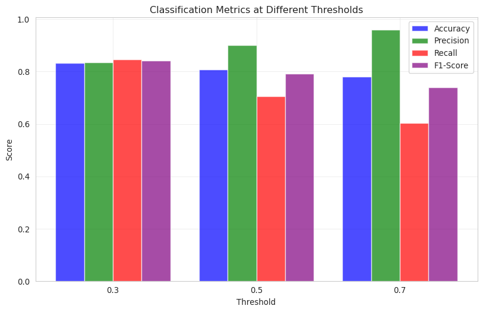

```python
# Analyze different thresholds
threshold_values = [0.3, 0.5, 0.7]
results = []

for threshold in threshold_values:
    y_pred_thresh = (y_pred_proba >= threshold).astype(int)
    acc = accuracy_score(y_test_c, y_pred_thresh)
    prec = precision_score(y_test_c, y_pred_thresh)
    rec = recall_score(y_test_c, y_pred_thresh)
    f1 = f1_score(y_test_c, y_pred_thresh)

    results.append({
        'Threshold': threshold,
        'Accuracy': acc,
        'Precision': prec,
        'Recall': rec,
        'F1-Score': f1
    })

results_df = pd.DataFrame(results)
print("Performance at Different Thresholds:")
print(results_df.to_string(index=False))

# Visualize threshold impact
fig, ax = plt.subplots(figsize=(10, 6))
x = np.arange(len(threshold_values))
width = 0.2

metrics = ['Accuracy', 'Precision', 'Recall', 'F1-Score']
colors = ['blue', 'green', 'red', 'purple']

for i, metric in enumerate(metrics):
    values = results_df[metric].values
    ax.bar(x + i * width, values, width, label=metric, color=colors[i], alpha=0.7)

ax.set_xlabel('Threshold')
ax.set_ylabel('Score')
ax.set_title('Classification Metrics at Different Thresholds')
ax.set_xticks(x + width * 1.5)
ax.set_xticklabels(threshold_values)
ax.legend()
ax.grid(True, alpha=0.3)
plt.show()
```

## Part 3: Cross-Validation

### 3.1 K-Fold Cross-Validation

Cross-validation provides a more robust estimate of model performance:

```python
# Perform k-fold cross-validation for regression
kfold = KFold(n_splits=5, shuffle=True, random_state=42)

# Regression cross-validation
reg_cv_scores = cross_val_score(LinearRegression(), X, y_true,
                                cv=kfold, scoring='r2')

print("Regression Model - 5-Fold Cross-Validation:")
print("-" * 40)
print(f"R² scores for each fold: {reg_cv_scores}")
print(f"Mean R² score: {reg_cv_scores.mean():.4f}")
print(f"Standard deviation: {reg_cv_scores.std():.4f}")
print(f"95% CI: [{reg_cv_scores.mean() - 2*reg_cv_scores.std():.4f}, "
      f"{reg_cv_scores.mean() + 2*reg_cv_scores.std():.4f}]")

# Classification cross-validation
clf_cv_scores = cross_val_score(LogisticRegression(random_state=42),
                                X_class, y_class,
                                cv=kfold, scoring='accuracy')

print("\nClassification Model - 5-Fold Cross-Validation:")
print("-" * 40)
print(f"Accuracy scores for each fold: {clf_cv_scores}")
print(f"Mean accuracy: {clf_cv_scores.mean():.4f}")
print(f"Standard deviation: {clf_cv_scores.std():.4f}")
print(f"95% CI: [{clf_cv_scores.mean() - 2*clf_cv_scores.std():.4f}, "
      f"{clf_cv_scores.mean() + 2*clf_cv_scores.std():.4f}]")
```

```
Regression Model - 5-Fold Cross-Validation:
----------------------------------------
R² scores for each fold: [0.81617775 0.67046568 0.72316442 0.76932369 0.72291915]
Mean R² score: 0.7404
Standard deviation: 0.0491
95% CI: [0.6421, 0.8387]

Classification Model - 5-Fold Cross-Validation:
----------------------------------------
Accuracy scores for each fold: [0.81 0.78 0.88 0.92 0.85]
Mean accuracy: 0.8480
Standard deviation: 0.0496
95% CI: [0.7489, 0.9471]
```

### 3.2 Visualizing Cross-Validation Results

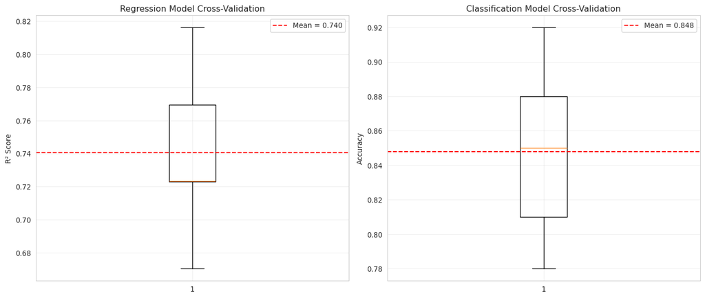

```python
fig, axes = plt.subplots(1, 2, figsize=(14, 6))

# Regression CV results
axes[0].boxplot(reg_cv_scores)
axes[0].set_ylabel('R² Score')
axes[0].set_title('Regression Model Cross-Validation')
axes[0].axhline(y=reg_cv_scores.mean(), color='r', linestyle='--',
                label=f'Mean = {reg_cv_scores.mean():.3f}')
axes[0].legend()
axes[0].grid(True, alpha=0.3)

# Classification CV results
axes[1].boxplot(clf_cv_scores)
axes[1].set_ylabel('Accuracy')
axes[1].set_title('Classification Model Cross-Validation')
axes[1].axhline(y=clf_cv_scores.mean(), color='r', linestyle='--',
                label=f'Mean = {clf_cv_scores.mean():.3f}')
axes[1].legend()
axes[1].grid(True, alpha=0.3)

plt.tight_layout()
plt.show()
```

## Part 4: Model Comparison

### 4.1 Comparing Multiple Models

```python
from sklearn.tree import DecisionTreeClassifier
from sklearn.ensemble import RandomForestClassifier
from sklearn.svm import SVC

# Define models to compare
models = {
    'Logistic Regression': LogisticRegression(random_state=42),
    'Decision Tree': DecisionTreeClassifier(random_state=42, max_depth=5),
    'Random Forest': RandomForestClassifier(random_state=42, n_estimators=100),
    'SVM': SVC(random_state=42, probability=True)
}

# Compare models
comparison_results = []

for name, model in models.items():
    # Train model
    model.fit(X_train_c, y_train_c)

    # Make predictions
    y_pred = model.predict(X_test_c)
    y_pred_proba = model.predict_proba(X_test_c)[:, 1] if hasattr(model, 'predict_proba') else None

    # Calculate metrics
    accuracy = accuracy_score(y_test_c, y_pred)
    precision = precision_score(y_test_c, y_pred)
    recall = recall_score(y_test_c, y_pred)
    f1 = f1_score(y_test_c, y_pred)
    auc_score = roc_auc_score(y_test_c, y_pred_proba) if y_pred_proba is not None else None

    comparison_results.append({
        'Model': name,
        'Accuracy': accuracy,
        'Precision': precision,
        'Recall': recall,
        'F1-Score': f1,
        'AUC': auc_score
    })

# Create comparison dataframe
comparison_df = pd.DataFrame(comparison_results)
comparison_df = comparison_df.sort_values('F1-Score', ascending=False)

print("Model Comparison Results:")
print("-" * 60)
print(comparison_df.to_string(index=False))
```

```
Model Comparison Results:
------------------------------------------------------------
              Model  Accuracy  Precision   Recall  F1-Score      AUC
                SVM  0.913333   0.957746 0.871795  0.912752 0.973469
      Random Forest  0.913333   0.971014 0.858974  0.911565 0.978098
      Decision Tree  0.860000   0.952381 0.769231  0.851064 0.930823
Logistic Regression  0.806667   0.901639 0.705128  0.791367 0.904736
```

### 4.2 Visualizing Model Comparison

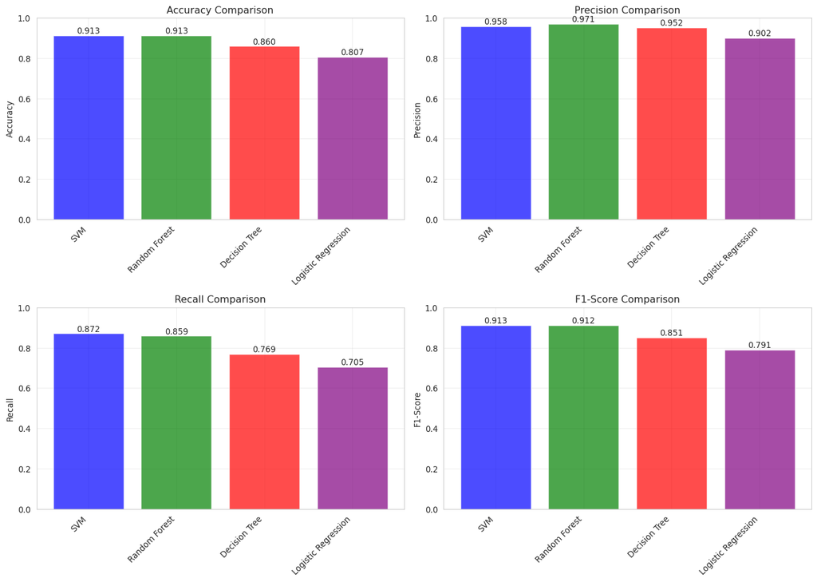

```python
# Create comparison visualization
fig, axes = plt.subplots(2, 2, figsize=(14, 10))

metrics_to_plot = ['Accuracy', 'Precision', 'Recall', 'F1-Score']

for idx, metric in enumerate(metrics_to_plot):
    ax = axes[idx // 2, idx % 2]

    colors = ['blue', 'green', 'red', 'purple']
    bars = ax.bar(comparison_df['Model'], comparison_df[metric], color=colors, alpha=0.7)

    ax.set_title(f'{metric} Comparison')
    ax.set_ylabel(metric)
    ax.set_ylim([0, 1])
    ax.grid(True, alpha=0.3)

    # Add value labels on bars
    for bar in bars:
        height = bar.get_height()
        ax.text(bar.get_x() + bar.get_width()/2., height,
                f'{height:.3f}', ha='center', va='bottom')

    # Rotate x-axis labels
    ax.set_xticklabels(comparison_df['Model'], rotation=45, ha='right')

plt.tight_layout()
plt.show()
```

### 4.3 ROC Curves Comparison

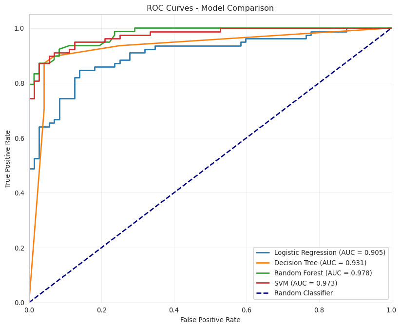

```python
plt.figure(figsize=(10, 8))

for name, model in models.items():
    if hasattr(model, 'predict_proba'):
        model.fit(X_train_c, y_train_c)
        y_pred_proba = model.predict_proba(X_test_c)[:, 1]
        fpr, tpr, _ = roc_curve(y_test_c, y_pred_proba)
        roc_auc = auc(fpr, tpr)

        plt.plot(fpr, tpr, lw=2, label=f'{name} (AUC = {roc_auc:.3f})')

plt.plot([0, 1], [0, 1], color='navy', lw=2, linestyle='--', label='Random Classifier')
plt.xlim([0.0, 1.0])
plt.ylim([0.0, 1.05])
plt.xlabel('False Positive Rate')
plt.ylabel('True Positive Rate')
plt.title('ROC Curves - Model Comparison')
plt.legend(loc="lower right")
plt.grid(True, alpha=0.3)
plt.show()
```

## Part 5: Business Context and Interpretation

### 5.1 Choosing Metrics for Business Problems

Different business problems require different evaluation priorities:

**Business Context Examples**

**Credit Card Fraud Detection** - **Priority**: Minimize false negatives (missing fraud) - **Key Metric**: Recall - **Reasoning**: Missing fraud is very costly

**Email Spam Filtering** - **Priority**: Balance precision and recall - **Key Metric**: F1-Score - **Reasoning**: Both spam in inbox and legitimate emails in spam are problematic

**Customer Churn Prediction** - **Priority**: Precision for targeted interventions - **Key Metric**: Precision - **Reasoning**: Retention campaigns are expensive, target likely churners

**Medical Diagnosis** - **Priority**: Minimize false negatives - **Key Metric**: Recall (Sensitivity) - **Reasoning**: Missing a disease can be life-threatening

### 5.2 Cost-Sensitive Evaluation

```python
# Define costs for a business scenario (e.g., loan default prediction)
cost_matrix = {
    'True Negative': 0,      # Correctly approved good loan
    'False Positive': -500,  # Rejected good loan (lost profit)
    'False Negative': -5000, # Approved bad loan (default loss)
    'True Positive': 0       # Correctly rejected bad loan
}

# Calculate total cost for our confusion matrix
tn, fp, fn, tp = cm.ravel()

total_cost = (tn * cost_matrix['True Negative'] +
              fp * cost_matrix['False Positive'] +
              fn * cost_matrix['False Negative'] +
              tp * cost_matrix['True Positive'])

avg_cost_per_prediction = total_cost / len(y_test_c)

print("Cost-Sensitive Analysis:")
print("-" * 40)
print(f"True Negatives cost:  ${tn * cost_matrix['True Negative']:,}")
print(f"False Positives cost: ${fp * cost_matrix['False Positive']:,}")
print(f"False Negatives cost: ${fn * cost_matrix['False Negative']:,}")
print(f"True Positives cost:  ${tp * cost_matrix['True Positive']:,}")
print(f"\nTotal Cost: ${total_cost:,}")
print(f"Average Cost per Prediction: ${avg_cost_per_prediction:,.2f}")
```

```
Cost-Sensitive Analysis:
----------------------------------------
True Negatives cost:  $0
False Positives cost: $-3,000
False Negatives cost: $-115,000
True Positives cost:  $0

Total Cost: $-118,000
Average Cost per Prediction: $-786.67
```

## Part 6: Advanced Topics

### 6.1 Handling Imbalanced Datasets

```python
# Create imbalanced dataset
from sklearn.datasets import make_classification

X_imb, y_imb = make_classification(
    n_samples=1000, n_features=10, n_informative=5,
    n_redundant=3, n_classes=2, weights=[0.9, 0.1],
    random_state=42, class_sep=1.0
)

print("Class Distribution:")
print(pd.Series(y_imb).value_counts())
print(f"\nClass Balance: {pd.Series(y_imb).value_counts()[1] / len(y_imb):.1%} positive class")

# Compare metrics with and without class weighting
X_train_imb, X_test_imb, y_train_imb, y_test_imb = train_test_split(
    X_imb, y_imb, test_size=0.3, random_state=42, stratify=y_imb
)

# Model without class weighting
clf_no_weight = LogisticRegression(random_state=42)
clf_no_weight.fit(X_train_imb, y_train_imb)
y_pred_no_weight = clf_no_weight.predict(X_test_imb)

# Model with class weighting
clf_weighted = LogisticRegression(class_weight='balanced', random_state=42)
clf_weighted.fit(X_train_imb, y_train_imb)
y_pred_weighted = clf_weighted.predict(X_test_imb)

# Compare results
print("\nModel Performance Comparison:")
print("-" * 50)
print("Without Class Weighting:")
print(f"  Precision: {precision_score(y_test_imb, y_pred_no_weight):.3f}")
print(f"  Recall:    {recall_score(y_test_imb, y_pred_no_weight):.3f}")
print(f"  F1-Score:  {f1_score(y_test_imb, y_pred_no_weight):.3f}")

print("\nWith Class Weighting:")
print(f"  Precision: {precision_score(y_test_imb, y_pred_weighted):.3f}")
print(f"  Recall:    {recall_score(y_test_imb, y_pred_weighted):.3f}")
print(f"  F1-Score:  {f1_score(y_test_imb, y_pred_weighted):.3f}")
```

```
Class Distribution:
0    896
1    104
Name: count, dtype: int64

Class Balance: 10.4% positive class

Model Performance Comparison:
--------------------------------------------------
Without Class Weighting:
  Precision: 0.545
  Recall:    0.194
  F1-Score:  0.286

With Class Weighting:
  Precision: 0.321
  Recall:    0.839
  F1-Score:  0.464
```

### 6.2 Feature Importance in Model Evaluation

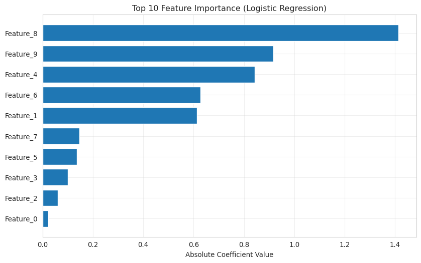

```
Top 5 Most Important Features:
     Feature  Coefficient
8  Feature_8     1.413320
9  Feature_9     0.916672
4  Feature_4     0.842368
6  Feature_6     0.626832
1  Feature_1     0.613101
```

```python
# Get feature importance from logistic regression
feature_importance = pd.DataFrame({
    'Feature': [f'Feature_{i}' for i in range(X_train_c.shape[1])],
    'Coefficient': np.abs(clf.coef_[0])
})
feature_importance = feature_importance.sort_values('Coefficient', ascending=False)

# Visualize feature importance
plt.figure(figsize=(10, 6))
plt.barh(feature_importance['Feature'][:10], feature_importance['Coefficient'][:10])
plt.xlabel('Absolute Coefficient Value')
plt.title('Top 10 Feature Importance (Logistic Regression)')
plt.gca().invert_yaxis()
plt.grid(True, alpha=0.3)
plt.show()

print("Top 5 Most Important Features:")
print(feature_importance.head())
```

## Summary and Best Practices

### Key Takeaways

1. **No Single Metric is Perfect**: Always use multiple metrics to evaluate your model
2. **Context Matters**: Choose metrics based on your business problem
3. **Cross-Validation**: Use it for robust performance estimates
4. **Visualization**: Always visualize your results for better understanding
5. **Compare Multiple Models**: Don’t settle for the first model that works

### Model Selection Checklist

**Model Selection Best Practices**

✅ **Define Success Metrics** based on business requirements  
✅ **Use Cross-Validation** for robust evaluation  
✅ **Check for Overfitting** using train vs. test performance  
✅ **Consider Model Complexity** vs. interpretability trade-offs  
✅ **Evaluate on Multiple Metrics** not just accuracy  
✅ **Test on Hold-out Data** for final validation  
✅ **Document Assumptions** and limitations  
✅ **Consider Deployment Constraints** (speed, memory, interpretability)

### Common Pitfalls to Avoid

**Common Mistakes**

❌ Using accuracy as the only metric for imbalanced datasets  
❌ Not checking for data leakage between train and test sets  
❌ Ignoring business costs when selecting models  
❌ Over-optimizing on a single metric  
❌ Not considering model interpretability requirements  
❌ Forgetting to scale features when comparing models

## Practice Exercises

Try these exercises to reinforce your understanding:

1. Load a dataset and compare at least 3 different models using appropriate metrics
2. Create a custom scoring function that incorporates business costs
3. Perform cross-validation and visualize the results
4. Generate ROC curves for multiple models and interpret the results
5. Handle an imbalanced dataset and compare different strategies

## Additional Resources

- [Scikit-learn Model Evaluation Documentation](https://scikit-learn.org/stable/modules/model_evaluation.html)
- [Google’s Machine Learning Crash Course - Classification](https://developers.google.com/machine-learning/crash-course/classification/video-lecture)
- [Towards Data Science - Model Evaluation Metrics](https://towardsdatascience.com/)

*Dr. Tim C. Smith ©️2025*  
*University of South Florida, ISM4641 Python for Business Analytics*

ISM4641 Python for Business - Version 0.12.0